# 1.7 — Price Elasticity — Practice Problems (Solutions)

ECON 306

The demand for monthly cell phone plans is given by:

$$q_D = 50-0.5p$$

### 1. Write the *inverse* demand function.

Simply take the demand function and solve it for $p$:

$$\begin{align*}
q_D&=50-0.5p\\
q_D+0.5p&=50\\
0.5p&=50-q_D\\
p&=100-2q_D\\
\end{align*}$$

The vertical intercept (“choke price”) is $100 and the slope is $-2$.

### 2. Calculate the price elasticity of demand when the price is $10. Is this relatively elastic or inelastic?

First we need to find $q_D$ at $10.

$$\begin{align*}
q_D&=50-0.5(10)\\
q_D&=50-5\\
q_D&=45\\
\end{align*}$$

Now we have the three ingredients to calculate elasticity at $10:

$$\begin{align*}
\epsilon_D &=\frac{1}{slope} \times \frac{p}{q_D} \\
\epsilon_D &=\frac{1}{-2} \times \frac{10}{45} \\
\epsilon_D &=-0.5 \times 0.22\\
\epsilon_D &=-0.11\\
\end{align*}$$

The demand is relatively inelastic, as $|\epsilon_D|<1$

### 3. Calculate the price elasticity of demand when the price is $70. Is this relatively elastic or inelastic?

First we need to find $q_D$ at $70.

$$\begin{align*}
q_D&=50-0.5(70)\\
q_D&=50-35\\
q_D&=15\\
\end{align*}$$

We already have the slope (since the demand is a straight line), so now we can simply plug into the elasticity formula:

$$\begin{align*}
\epsilon_D &=\frac{1}{slope} \times \frac{p}{q_D} \\
\epsilon_D &=\frac{1}{-2} \times \frac{70}{15}\\
\epsilon_D &=-0.5 \times 4.67\\
\epsilon_D &\approx -2.33\\
\end{align*}$$

The demand is relatively elastic, as $|\epsilon_D|>1$

### 4. At what price is demand unit elastic $(\epsilon=-1)$?

$$\begin{align*}
\epsilon_D &=\frac{1}{slope} \times \frac{p}{q_D} & & \text{Formula for elasticity}\\
-1&=-0.5 \times \frac{p}{q_D} & & \text{Set } \epsilon_D \text{ equal to }-1\\
-1&=-0.5 \times \frac{p}{(50-0.5p)} & & \text{Plug in demand function for } q_D\\
-1(50-0.5p)&=-0.5p & & \text{Multiply by term in parentheses}\\
0.5p-50&=-0.5p & & \text{Distribute the }-1 \\
-50&=-p & & \text{Add } 0.5p\\
p&=\$50 & & \text{Divide by }-50\\
\end{align*}$$

### 5. Calculate the total revenue at $10.

The total revenue is:

$$\begin{align*}
R&=pq\\
R&=(\$10)(45)\\
R&=\$450\\
\end{align*}$$

### 6. Calculate the total revenue at $70.

The total revenue is:

$$\begin{align*}
R&=pq\\
R&=(\$70)(15)\\
R&=\$1,050\\
\end{align*}$$

### 7. Calculate the total revenue at the price you found for question 4.

That price was $p=\$50$. At this price, we need to find the quantity demanded. We can use the demand function:

$$\begin{align*}
q_D&=50-0.5p\\
q_D&=50-0.5(50)\\
q_D&=50-25\\
q_D&=25\\
\end{align*}$$

Now that we have price and quantity, revenue is:

$$\begin{align*}
R& = pq\\
R&=(\$50)(25)\\
R&=\$1,250\\
\end{align*}$$

This is where revenue is maximized.

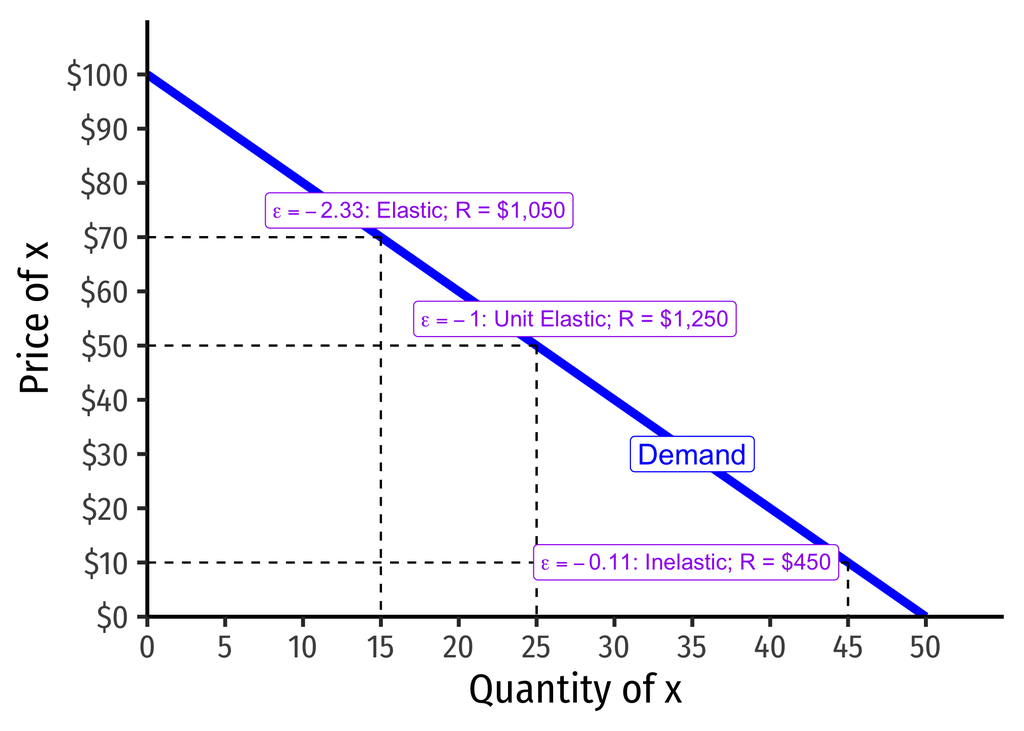